# Practice1 - Data Manipulation (Team 1)

### Loading data

```r
owid <-
  read.csv('http://github.com/owid/covid-19-data/raw/master/public/data/owid-covid-data.csv', stringsAsFactors=F)

dim(owid)
```

```
## [1] 114995     62
```

```r
head(names(owid))
```

```
## [1] "iso_code"    "continent"   "location"    "date"        "total_cases"
## [6] "new_cases"
```

### 1. Column selection

```r
owid_selected <-
  owid %>% select(iso_code, continent, location, date, new_cases, new_deaths, new_cases_per_million,
                  new_deaths_per_million, reproduction_rate, icu_patients, icu_patients_per_million,
                  hosp_patients, hosp_patients_per_million, weekly_icu_admissions,
                  weekly_icu_admissions_per_million, weekly_hosp_admissions,
                  weekly_hosp_admissions_per_million, new_tests, new_tests_per_thousand, positive_rate,
                  total_vaccinations, people_vaccinated, people_fully_vaccinated, new_vaccinations,
                  people_vaccinated_per_hundred, people_fully_vaccinated_per_hundred, stringency_index,
                  population, population_density, median_age, aged_65_older, aged_70_older, gdp_per_capita,
                  extreme_poverty, cardiovasc_death_rate, diabetes_prevalence, female_smokers,
                  male_smokers, handwashing_facilities, hospital_beds_per_thousand, life_expectancy,
                  human_development_index, excess_mortality)

dim(owid_selected)
```

```
## [1] 114995     43
```

```r
names(owid_selected)
```

```
##  [1] "iso_code"                            "continent"
##  [3] "location"                            "date"
##  [5] "new_cases"                           "new_deaths"
##  [7] "new_cases_per_million"               "new_deaths_per_million"
##  [9] "reproduction_rate"                   "icu_patients"
## [11] "icu_patients_per_million"            "hosp_patients"
## [13] "hosp_patients_per_million"           "weekly_icu_admissions"
## [15] "weekly_icu_admissions_per_million"   "weekly_hosp_admissions"
## [17] "weekly_hosp_admissions_per_million"  "new_tests"
## [19] "new_tests_per_thousand"              "positive_rate"
## [21] "total_vaccinations"                  "people_vaccinated"
## [23] "people_fully_vaccinated"             "new_vaccinations"
## [25] "people_vaccinated_per_hundred"       "people_fully_vaccinated_per_hundred"
## [27] "stringency_index"                    "population"
## [29] "population_density"                  "median_age"
## [31] "aged_65_older"                       "aged_70_older"
## [33] "gdp_per_capita"                      "extreme_poverty"
## [35] "cardiovasc_death_rate"               "diabetes_prevalence"
## [37] "female_smokers"                      "male_smokers"
## [39] "handwashing_facilities"              "hospital_beds_per_thousand"
## [41] "life_expectancy"                     "human_development_index"
## [43] "excess_mortality"
```

주어진 조건에 따라서 기존의 owid 데이터프레임에서 일부 Columns만 추출하도록 한다.

### 2. Excluding non-country location

```r
owid_countries <-
  owid_selected %>%
    filter(!location %in% c('Africa', 'Asia', 'Europe', 'European Union',
                            'International', 'North America', 'Oceania',
                            'South America', 'World'))

dim(owid_countries)
```

```
## [1] 109723     43
```

```r
length(unique(owid_countries$location))
```

```
## [1] 224
```

owid_selected 데이터프레임에서 location 열에 있는 값들 중, 나라의 이름이 아닌 대륙 등의 이름을 가지고 있는 것들을 제거해준다.

### 3. Changing column names

```r
colnames(owid_countries) <- gsub('^new_', 'daily_', colnames(owid_countries))

owid_countries %>%
  select(starts_with('daily_')) %>%
  head()
```

```
##   daily_cases daily_deaths daily_cases_per_million daily_deaths_per_million
## 1           1           NA                   0.025                       NA
## 2           0           NA                   0.000                       NA
## 3           0           NA                   0.000                       NA
## 4           0           NA                   0.000                       NA
## 5           0           NA                   0.000                       NA
## 6           0           NA                   0.000                       NA
##   daily_tests daily_tests_per_thousand daily_vaccinations
## 1          NA                       NA                 NA
## 2          NA                       NA                 NA
## 3          NA                       NA                 NA
## 4          NA                       NA                 NA
## 5          NA                       NA                 NA
## 6          NA                       NA                 NA
```

owid_countries 데이터프레임의 열들 중에서 ’new’로 시작하는 열들의 이름을 ’daily’로 시작하게 바꾸도록 한다.

### 4. Change type of column

```r
owid_countries$date <- as.Date(owid_countries$date)
str(owid_countries)
```

```
## 'data.frame':    109723 obs. of  43 variables:
##  $ iso_code                           : chr  "AFG" "AFG" "AFG" "AFG" ...
##  $ continent                          : chr  "Asia" "Asia" "Asia" "Asia" ...
##  $ location                           : chr  "Afghanistan" "Afghanistan" "Afghanistan" "Afghanistan" ...
##  $ date                               : Date, format: "2020-02-24" "2020-02-25" ...
##  $ daily_cases                        : num  1 0 0 0 0 0 0 0 1 2 ...
##  $ daily_deaths                       : num  NA NA NA NA NA NA NA NA NA NA ...
##  $ daily_cases_per_million            : num  0.025 0 0 0 0 0 0 0 0.025 0.05 ...
##  $ daily_deaths_per_million           : num  NA NA NA NA NA NA NA NA NA NA ...
##  $ reproduction_rate                  : num  NA NA NA NA NA NA NA NA NA NA ...
##  $ icu_patients                       : num  NA NA NA NA NA NA NA NA NA NA ...
##  $ icu_patients_per_million           : num  NA NA NA NA NA NA NA NA NA NA ...
##  $ hosp_patients                      : num  NA NA NA NA NA NA NA NA NA NA ...
##  $ hosp_patients_per_million          : num  NA NA NA NA NA NA NA NA NA NA ...
##  $ weekly_icu_admissions              : num  NA NA NA NA NA NA NA NA NA NA ...
```

[output cut: 29 more lines]

owid_countries 데이터프레임의 date 열의 type을 Date 타입으로 바꾸고, str 함수를 통해서 잘 바뀌었는지 확인한다.

### 5. Proportion of COVID-19 contracted people

```r
owid_countries <-
  owid_countries %>%
    group_by(location) %>%
    mutate(cumulative_cases = cumsum(replace_na(daily_cases, 0)),
           prop_contr_people_column = cumulative_cases / population)

owid_countries %>%
  select(location, daily_cases, cumulative_cases, prop_contr_people_column) %>%
  head(20)
```

```
## # A tibble: 20 × 4
## # Groups:   location [1]
##    location    daily_cases cumulative_cases prop_contr_people_column
##    <chr>             <dbl>            <dbl>                    <dbl>
##  1 Afghanistan           1                1             0.0000000251
##  2 Afghanistan           0                1             0.0000000251
##  3 Afghanistan           0                1             0.0000000251
##  4 Afghanistan           0                1             0.0000000251
##  5 Afghanistan           0                1             0.0000000251
##  6 Afghanistan           0                1             0.0000000251
##  7 Afghanistan           0                1             0.0000000251
##  8 Afghanistan           0                1             0.0000000251
##  9 Afghanistan           1                2             0.0000000502
## 10 Afghanistan           2                4             0.000000100
## 11 Afghanistan           0                4             0.000000100
## 12 Afghanistan           0                4             0.000000100
## 13 Afghanistan           0                4             0.000000100
## 14 Afghanistan           1                5             0.000000126
## 15 Afghanistan           2                7             0.000000176
## 16 Afghanistan           1                8             0.000000201
## 17 Afghanistan           3               11             0.000000276
## 18 Afghanistan           1               12             0.000000301
## 19 Afghanistan           1               13             0.000000326
## 20 Afghanistan           2               15             0.000000377
```

owid_countries 데이터프레임에서 누적 확진자의 전체 인구 대비 비율을 계산하도록 한다.

그런데 확인해보니, 누적 확진자에 대한 데이터가 없기 때문에 cumsum 함수를 통해서 누적 확진자 데이터를 만들어주도록 한다.

이때, cumsum 함수는 NA를 자동으로 처리해주지 못하기 때문에 replace_na 함수를 통해서 NA는 0으로 바꾸고, 계산해주도록 한다.

그 후, 문제에 따라서 cumulative_cases에 population을 나눠서 누적 확진자의 전체 인구 대비 비율을 계산하도록 한다.

```r
owid_countries %>%
  filter(date == max(owid_countries$date)) %>%
  arrange(desc(prop_contr_people_column)) %>%
  select(location, date, cumulative_cases, population, prop_contr_people_column) %>%
  head(8)
```

```
## # A tibble: 8 × 5
## # Groups:   location [8]
##   location   date       cumulative_cases population prop_contr_people_column
##   <chr>      <date>                <dbl>      <dbl>                    <dbl>
## 1 Seychelles 2021-09-06            20230      98910                    0.205
## 2 Andorra    2021-09-06            15069      77354                    0.195
## 3 Montenegro 2021-09-06           118466     628051                    0.189
## 4 San Marino 2021-09-06             5345      34010                    0.157
## 5 Czechia    2021-09-06          1680697   10724553                    0.157
## 6 Bahrain    2021-09-06           273113    1748295                    0.156
## 7 Maldives   2021-09-06            82099     543620                    0.151
## 8 Georgia    2021-09-06           565957    3979773                    0.142
```

누적 확진자의 전체 인구 대비 비율을 계산한 후, 가장 최근 날짜 기준으로 데이터를 filter 하도록 한다. 그리고 가장 상위 5개 나라와 그 결과를 출력한다.

상위 5개 나라는 Seychelles, Andorra, Montenegro, San Marion, Czechia로 나오는 것을 확인할 수 있다.

```r
owid_countries %>%
  filter(date == max(owid_countries$date)) %>%
  arrange(desc(prop_contr_people_column)) %>%
  select(location, date, cumulative_cases, population, prop_contr_people_column) %>%
  filter(prop_contr_people_column == 0)
```

```
## # A tibble: 8 × 5
## # Groups:   location [8]
##   location       date       cumulative_cases population prop_contr_people_column
##   <chr>          <date>                <dbl>      <dbl>                    <dbl>
## 1 Aruba          2021-09-06                0     107195                        0
## 2 Cayman Islands 2021-09-06                0      66498                        0
## 3 Curacao        2021-09-06                0     164796                        0
## 4 Faeroe Islands 2021-09-06                0      49053                        0
## 5 Greenland      2021-09-06                0      56868                        0
## 6 Guernsey       2021-09-06                0      67052                        0
## 7 Isle of Man    2021-09-06                0      85410                        0
## 8 Macao          2021-09-06                0     658391                        0
```

하위 5개 나라와 그 결과를 출력한다. (전체 인구 대비 감염된 percentage가 낮은 나라들)

하위 5개 나라는 확진자 비율이 0인 국가들인데, 이런 국가가 총 8개가 있다.

그 국가들은 Aruba, Cayman Islands, Curacao, Faeroe Islands, Greenland, Guernsey, Isle of Man, Macao 이다.

### 6. 백신 접종 격차에 대해

```r
vaccinations_gdp <-
  owid_countries %>%
  group_by(location) %>%
  fill(people_vaccinated, .direction = c('down')) %>%
  filter(date == max(owid_countries$date)) %>%
  mutate(people_vaccinated = ifelse(is.na(people_vaccinated), 0, people_vaccinated),
         v_rate = people_vaccinated / population,
         v_rate_group = cut(v_rate, breaks = c(-Inf, 0.1, 0.5, Inf),
                            labels = c('under_10%', '10%~50%', 'over_50%')))

vaccinations_gdp %>%
  group_by(v_rate_group) %>%
  summarise(GDP_mean = mean(na.omit(gdp_per_capita))) %>%
  arrange(desc(GDP_mean))
```

```
## # A tibble: 3 × 2
##   v_rate_group GDP_mean
##   <fct>           <dbl>
## 1 over_50%       38141.
## 2 10%~50%        12637.
## 3 under_10%       3789.
```

백신 접종률을 계산하기 위해 누적 백신 접종자 수를 계산하도록 한다.

백신 접종은 한 번이라도 맞은 사람(people_vaccinated)과 1차와 2차 접종을 모두 한 사람(people_fully_vaccinated)으로 나뉜다.

여기서 백신 보급의 양극화에 대해 알아보려고 하기 때문에 한 번이라도 맞은 사람의 비율을 계산해본다.

이를 위해서 people_vaccinated 데이터에는 NA가 많이 있기 때문에 time series 기준으로 전날의 값들로 NA를 채워주도록 한다. (fill(.direction = c(‘down’)))

그리고 people_vaccinated를 population으로 나눠서 백신 접종률(v_rate)을 구하고, cut 함수로 그룹을 나눠주도록 한다.

최종적으로는 각 그룹 별로의 GDP의 평균 값을 계산한다.

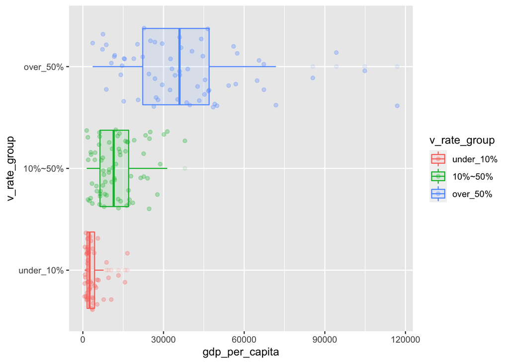

```r
vaccinations_gdp %>%
  select(location, gdp_per_capita, v_rate, v_rate_group) %>%
  ggplot(mapping = aes(x = v_rate_group, y = gdp_per_capita)) +
  geom_boxplot(alpha = 0.1, aes(col = v_rate_group, fill = v_rate_group)) +
  geom_jitter(alpha = 0.3, aes(col = v_rate_group)) +
  coord_flip()
```

이를 boxplot으로 표현해보면, 조금 더 직관적으로 확인할 수 있다.

위에서 출력한 평균값과 일치하게, 백신 접종률이 높은 국가들이 전반적으로 GDP가 높은 것을 볼 수 있다.

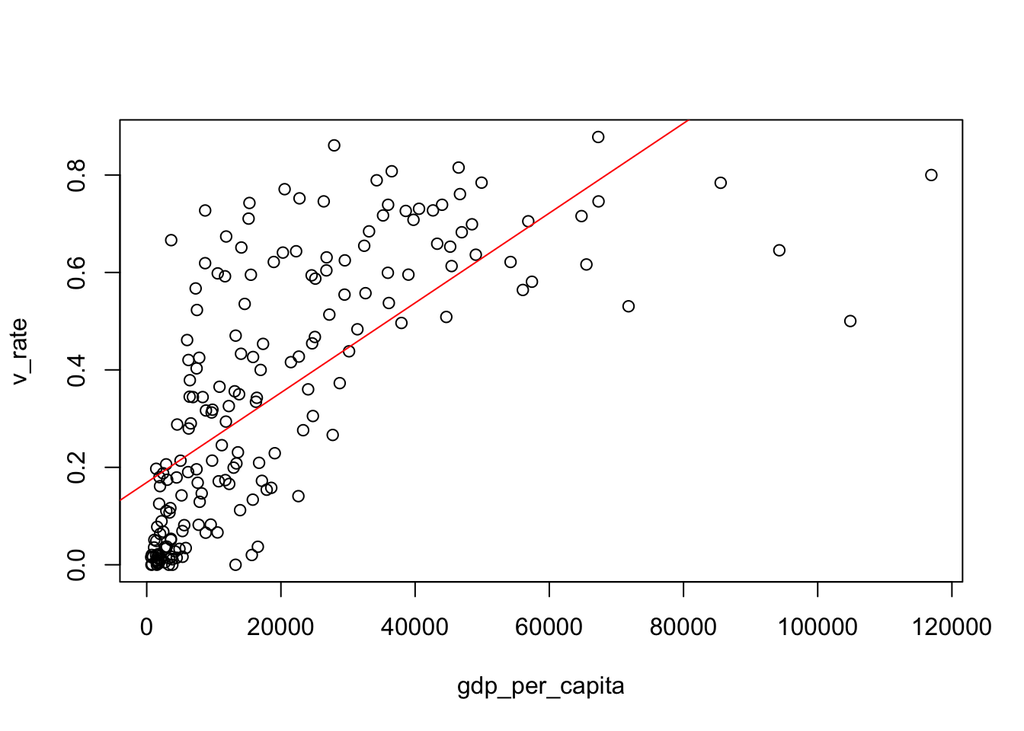

```r
v_df <- vaccinations_gdp %>%
          select(location, gdp_per_capita, v_rate, v_rate_group)

plot(v_rate ~ gdp_per_capita, data = v_df)
abline(lm(v_rate ~ gdp_per_capita, data = v_df), col = 'red')
```

조금 더 자세히 확인해보기 위하여 X축을 GDP로, Y축을 백신 접종률로 하여 plot과 회귀선을 그려본다.

그 결과 y=x 형태의 일차식 그래프가 나오는 것을 확인할 수 있으며, GDP가 커질수록 백신 접종률이 높아진다.

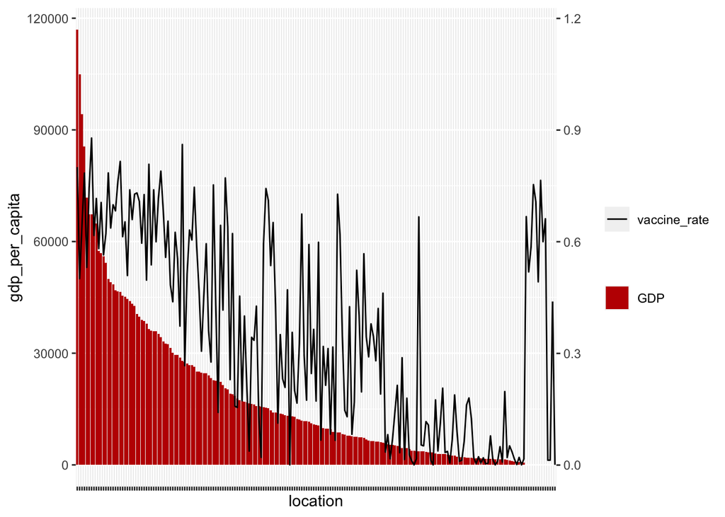

```r
ggplot(vaccinations_gdp, aes(x = location)) +
  geom_col(aes(x = reorder(location, -gdp_per_capita), y = gdp_per_capita, fill = 'redfill')) +
  geom_line(aes(y = v_rate*100000, group = 1, color = 'blackline')) +
  scale_y_continuous(sec.axis = sec_axis(trans = ~ . / 100000)) +
  scale_fill_manual('', labels = 'GDP', values = "#C00000") +
  scale_color_manual('', labels = 'vaccine_rate', values = 'black') +
  theme(axis.text.x = element_blank())
```

국가 경제 수준에 따라 백신 보급의 편차가 심한지를 알아보기 위해서 백신 접종률과 GDP를 그래프로 표현하여 그 분포를 확인해보도록 한다.

X축은 각 나라가, Y축에서 막대는 GDP를, 선은 백신 접종률을 의미한다.

그 결과를 보면, GDP가 높다고 해서 무조건 백신 접종률이 높은 것으로 보이지는 않는다.

다만, GDP가 낮은 국가의 백신 접종률은 다른 나라들에 비해 현저히 떨어지는 것은 확인된다.

또한 백신 접종률에 따른 그룹 별로 GDP의 평균 값에서 볼 수 있듯, 어느 정도는 GDP와 백신 접종률 사이의 관계가 있는 것으로 판단된다.

### 7. Continent comparison

```r
v_gap_stat <-
  vaccinations_gdp %>%
    group_by(continent) %>%
    summarise(population_sum = sum(population),
              population_density_mean = mean(population_density, na.rm = T),
              cumulative_cases_mean = mean(cumulative_cases, na.rm = T),
              gdp_mean = mean(gdp_per_capita, na.rm = T),
              v_rate_mean = mean(v_rate, na.rm = T),
              median_age_mean = mean(median_age, na.rm = T),
              life_expectancy_mean = mean(life_expectancy, na.rm = T),
              develop_index_mean = mean(human_development_index, na.rm = T)) %>%
    arrange(population_sum)

v_gap_stat
```

```
## # A tibble: 6 × 9
##   continent    population_sum population_density_m… cumulative_cases_m… gdp_mean
##   <chr>                 <dbl>                 <dbl>               <dbl>    <dbl>
## 1 Oceania            42204801                  76.4              12217.   11523.
## 2 South Ameri…      433950159                  24.4            3088611.   13841.
## 3 North Ameri…      592607340                 203.             1781584.   19277.
## 4 Europe            750743188                 566.             1159598.   33361.
## 5 Africa           1371687302                 103.              146879.    5444.
## 6 Asia             4646440014                1025.             1472551.   24719.
## # … with 4 more variables: v_rate_mean <dbl>, median_age_mean <dbl>,
## #   life_expectancy_mean <dbl>, develop_index_mean <dbl>
```

대륙 별로 총 인구 수, 평균 인구 밀도, GDP의 평균, median age의 평균, 기대수명률의 평균, development_index의 평균 등의 지표를 비교해본다.

또한 대륙 별로의 누적 확진자 평균과 백신 접종률의 평균을 계산해본다.

#### 7-1. 대륙 별 인구 수

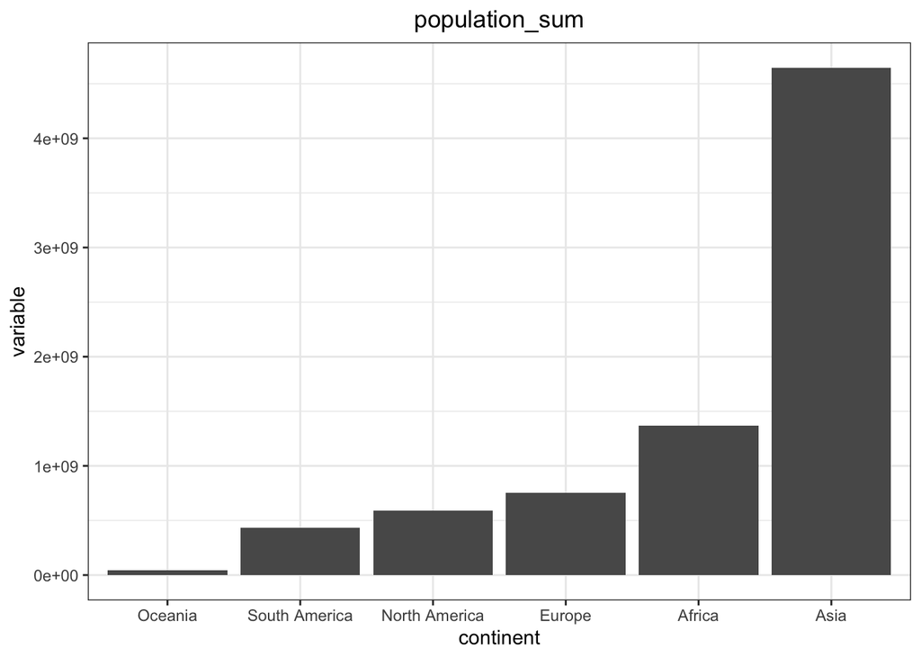

```r
print_plot <- function(variable, title){
  v_gap_stat %>%
    ggplot(aes(x = reorder(continent, variable), y = variable)) +
    theme_bw() + geom_col() + xlab("continent") +
    ggtitle(title) +
    theme(plot.title = element_text(hjust=0.5))
}

print_plot(v_gap_stat$population_sum, 'population_sum')
```

각 대륙 별로 원하는 변수의 전반적인 분포를 확인할 수 있는 print_plot 이라는 함수를 정의한다.

그리고 가장 처음으로는, 대륙 별로의 인구 수를 확인하는 그래프를 그려보았다.

이 그래프를 통해서 알 수 있는 것은 Asia - Africa - Europe .. 순으로 인구 수가 많다.

#### 7-2. 대륙 별 평균 인구 밀도

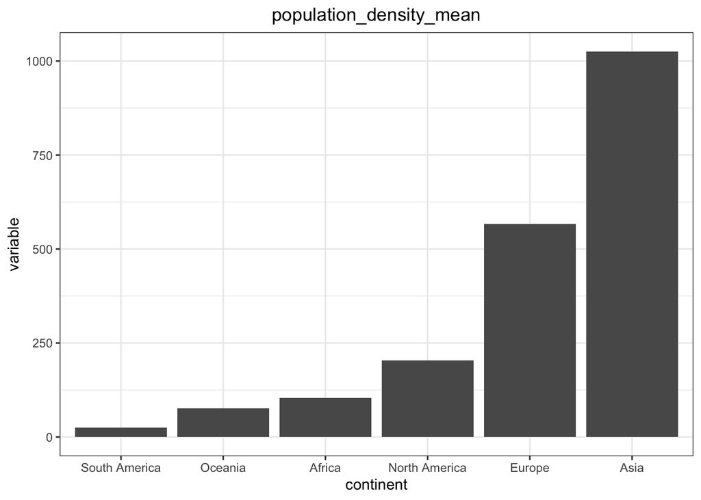

```r
print_plot(v_gap_stat$population_density_mean, 'population_density_mean')
```

두번째로는, 대륙 별로 평균 인구 밀도를 알아본다.

그래프를 통해서 인구 수가 가장 많았던 Asia가 평균 인구 밀도가 가장 높은 것을 볼 수 있다.

#### 7-3. 대륙 별 평균 GDP

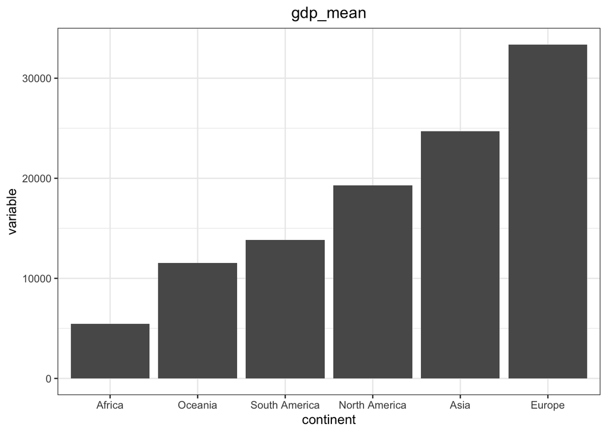

```r
print_plot(v_gap_stat$gdp_mean, 'gdp_mean')
```

세번째로는, 대륙 별로 평균 GDP를 알아본다.

그래프를 통해서 GDP가 가장 높았던 대륙은 Europe이고, Africa가 가장 GDP가 낮았다.

#### 7-4. 대륙 별 평균 Median age

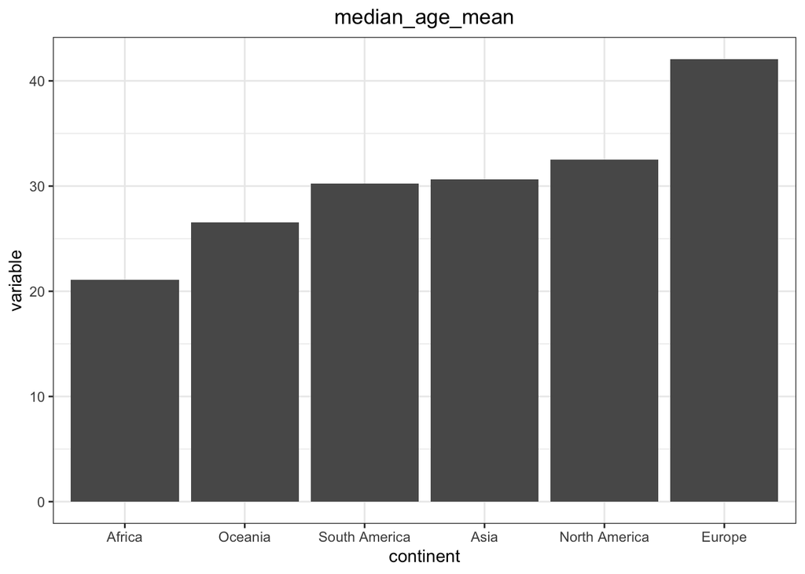

```r
print_plot(v_gap_stat$median_age_mean, 'median_age_mean')
```

네번째로는, 대륙 별로 평균 Median age를 알아본다.

그래프를 통해서 중위 나이가 가장 높고, 낮은 대륙은 GDP와 동일하게 Europe과 Africa 였다.

#### 7-5. 기타

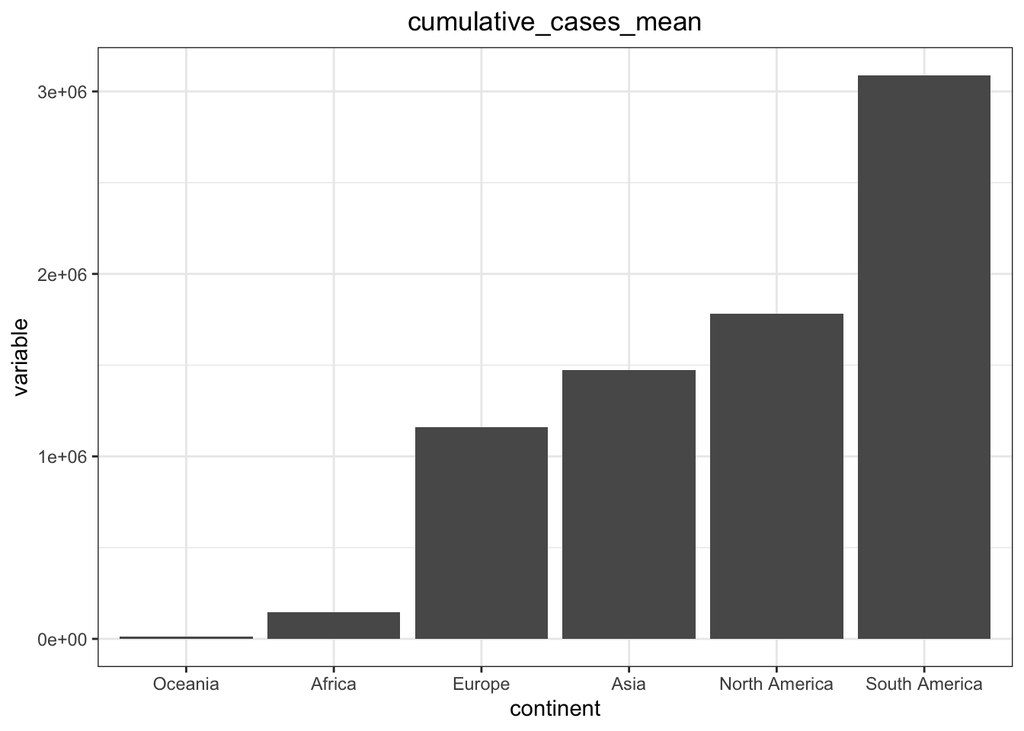

```r
print_plot(v_gap_stat$cumulative_cases_mean, 'cumulative_cases_mean')
```

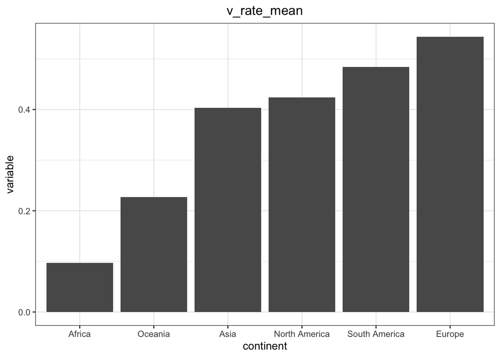

```r
print_plot(v_gap_stat$v_rate_mean, 'v_rate_mean')
```

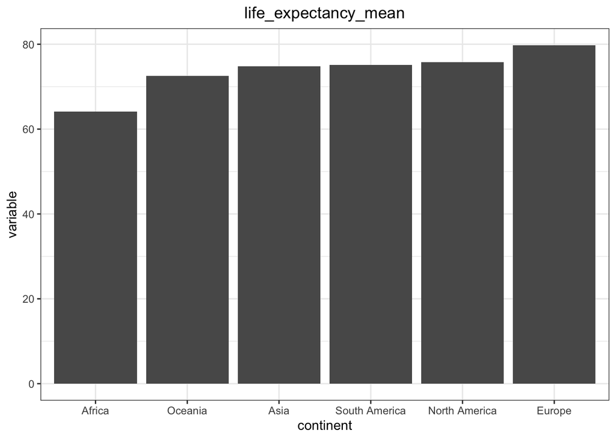

```r
print_plot(v_gap_stat$life_expectancy_mean, 'life_expectancy_mean')
```

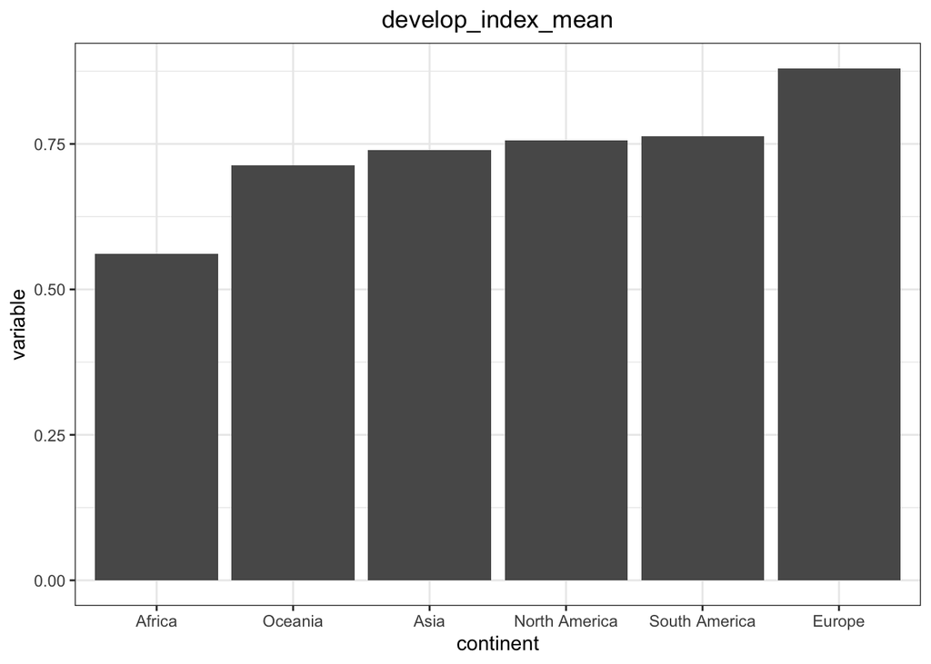

```r
print_plot(v_gap_stat$develop_index_mean, 'develop_index_mean')
```

기타 분포를 확인하기 위해서 누적 확진자 수, 평균 접종률, 평균 기대수명, develop_index 값을 확인했다.

위와 같은 과정들을 통해서 전반적으로 알 수 있었던 것은 다음과 같다.

1. 인구 수가 가장 많고, 평균 인구 밀도가 가장 높은 아시아는 생각 보다 누적 확진자 수가 많지 않다.
2. 평균 인구 밀도가 가장 낮았던 South America가 오히려 누적 확진자 수가 가장 많았다.
3. GDP의 평균이 가장 높았던 Europe이 평균 백신 접종률이 가장 높았다.
4. GDP의 평균이 가장 낮았던 Africa의 평균 백신 접종률이 가장 낮았다.

### 8. Stringency_index vs. Reproduction_rate

```r
df <- owid_countries %>%
        filter(reproduction_rate >= 0) %>%
        select(location, date, stringency_index, reproduction_rate) %>%
        drop_na()

head(df)
```

```
## # A tibble: 6 × 4
## # Groups:   location [1]
##   location    date       stringency_index reproduction_rate
##   <chr>       <date>                <dbl>             <dbl>
## 1 Afghanistan 2020-03-29             67.6              1.46
## 2 Afghanistan 2020-03-30             67.6              1.47
## 3 Afghanistan 2020-03-31             67.6              1.47
## 4 Afghanistan 2020-04-01             67.6              1.47
## 5 Afghanistan 2020-04-02             67.6              1.47
## 6 Afghanistan 2020-04-03             67.6              1.46
```

stringency_index와 reproduction_rate을 통해서 높은 수준의 사회적 통제가 전염병 확산 속도에 영향을 주는지 확인보도록 한다.

이를 확인하기 위해 데이터를 먼저 추렸는데, 확인해보니 reproduction_rate에 -0.01이라는 값이 4개가 있는 것을 보았다.

reproduction_rate 변수는 한 명의 확진자가 추가로 얼마나 확진시키는지에 대한 것이므로 이를 Outlier로 생각하여 제거했다.

```r
cor(df$stringency_index, df$reproduction_rate)
```

```
## [1] 0.1542859
```

이에 대한 해석은 한 변수의 값이 커질 때, 다른 변수의 값도 약간은 커지는 약한 양적 선형관계를 뜻한다.

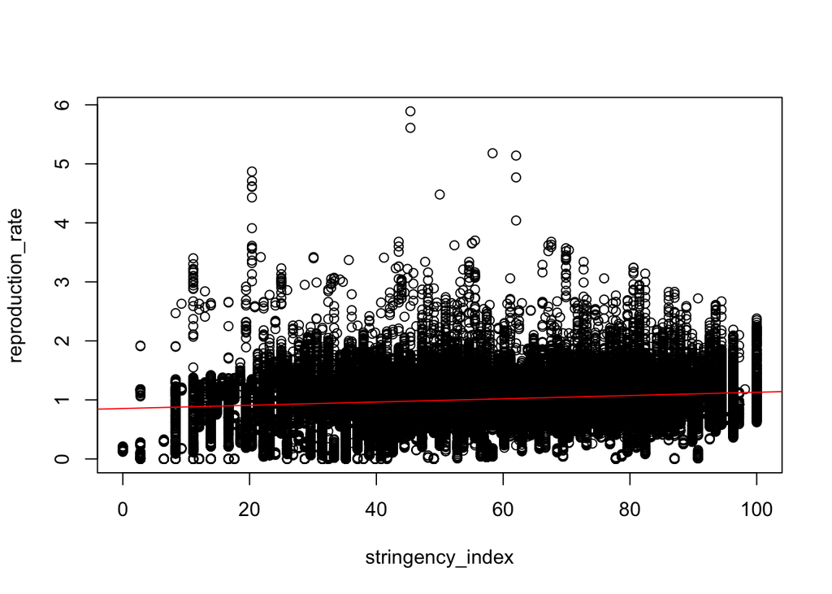

```r
plot(reproduction_rate ~ stringency_index, data = df)
abline(lm(reproduction_rate ~ stringency_index, data = df), col = 'red')
```

이를 조금 더 직관적으로 확인해보기 위하여 산점도를 그리고, 그에 따른 회귀 그래프를 그려보았다.

X축이 stringency_index이고, Y축이 reproduction_rate인데 기울기가 작기는 하지만 X축이 커질수록, 미세하게 나마 Y축의 값이 커지는 모습을 보인다.

따라서 상관계수의 해석과 그래프를 통해서 볼 때, 높은 수준의 사회적 통제는 전염병의 확산 속도를 줄이는데 큰 영향을 미치지 않는 것으로 사료된다.

```r
df %>%
  mutate(stringency_index_group = cut(stringency_index, breaks = c(-Inf, seq(10, 90, 10), Inf),
                                      labels = c('0~10', '10~20', '20~30', '30~40', '40~50',
                                                 '50~60', '60~70', '70~80', '80~90', '90~100'))) %>%
  group_by(stringency_index_group) %>%
  summarise(mean(reproduction_rate))
```

```
## # A tibble: 10 × 2
##    stringency_index_group `mean(reproduction_rate)`
##    <fct>                                      <dbl>
##  1 0~10                                       0.352
##  2 10~20                                      0.810
##  3 20~30                                      0.945
##  4 30~40                                      0.963
##  5 40~50                                      1.02
##  6 50~60                                      1.03
##  7 60~70                                      1.04
##  8 70~80                                      1.03
##  9 80~90                                      1.06
## 10 90~100                                     1.16
```

이를 조금 더 자세히 확인해보기 위해서 0부터 100까지 값으로 나뉜 사회통제 수준을 10 단위로 하여 group을 만든다.

그리고 나뉜 각 그룹에 대하여 reproduction_rate의 평균을 계산해본다.

그 결과를 보면, 위에서 이야기 했던 상관계수와 그래프의 모양처럼 사회통제 수준이 강해질수록 오히려 reproduction_rate의 평균이 증가함을 볼 수 있다.

그래서 추측해보건데, 이미 코로나의 확산도가 심해졌기 때문에 뒤늦게나마 사회통제 수준을 올리게 되어 이런 결과가 나오지 않았을까 생각해보았다.